# CPS305 Fall 2019

## Lab 01 Report

## Sameer Naumani, Std ID 500703778

12/9/2019

# Introduction and Overall Comments

The goal of this lab is to explore the infinite monkey theorem using python functions. The theorem states that a monkey hitting keys at random on a typewriter keyboard for an infinite amount of time will almost surely type a given text, such as the complete works of William Shakespeare. The following python code runs this experiment by generating random letters from the alphabet and comparing it to our target sentence. The target sentence is: “methinks it is like a weasel”.

The program will then compare the random letters to our target sentence and will score each try. If the score is not 100% it will try again, constantly updating the best score and letters every 100 tries. As expected, this can take a very long time to finally complete depending on the target string but in the end it was able to prove the thereom.

## Solution for exercise 1

```
String   Score  Try
leapiextfwsuxsrdknokxgcpjdgs    10.714286 0
methinks it isolike a weasel    96.428571 100
methinks it is like a weasel    100.000000 145
```

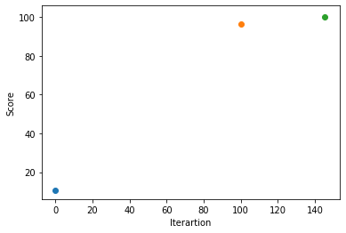

```python
from mySolution import monkeyTypist

monkeyTypist()
```

**Discussion of the Results** The results show that the solution can be solved despite the very large amount of iterations. In one execution of the program it only took 127 tries to complete. The reason being the code has been optimized so that every time a letter is typed correctly it remains in memory, and the incorrect letters are randomly typed. In the normal case it would take over a millio tries to complete if we generated a new random string each time.

## Solution for Exercise 2

```python
# Python code and its output
# Test cases

import unittest
from mySolution import generate
from mySolution import calcScore

class TestGenerate(unittest.TestCase):

  ######## test to see if the generator generates the correct number of terms ########3
    def test_generate(self):
        target = "methinks it is like a weasel"
        lenS = len(target)
        print(lenS)
        alphabet = list("abcdefghijklmnopqrstuvwxyz")
        lenA = len(alphabet)
        for i in range(10):
            string = generate(lenS, lenA, alphabet)
            print(len(string))
            self.assertEqual(len(string), lenS, "Should be equal to 28")

    def test_score(self):
        data = calcScore("heddo", "hello")
        self.assertTrue(50.0)


if __name__ == '__main__':
    unittest.main(argv=['first-arg-is-ignored'], exit=False)
    # if running the above from the REPL use unittest.main() instead
```

```
..
```

```
28
28
28
28
28
28
28
28
28
28
28
```

```
----------------------------------------------------------------------
Ran 2 tests in 0.015s

OK
```

**Discussion of the Results**